# Homework 2

Author

Ethan Lee

# I am using my first late submission for this assignment.

## Homework 2

### Part One: Analyzing the Weather

In this section, you will gain more practice working with public APIs, this time using a public weather API, [WeatherAPI](https://www.weatherapi.com/). The first thing you’ll need to access the API is an API key. You can sign up for a key here: https://www.weatherapi.com/signup.aspx

#### Exercise 1

Use the http://api.weatherapi.com/v1/current.json URL to access the API and obtain real-time weather data. Note that you will want to specify three query parameters, at least – `key`, which should be set to your individual API key, `q`, which should equal the city name of a specified location – for example `q = "Isla Vista"` – and `aqi`, which indicates whether you want to obtain air quality data (`"yes"` or `"no"`).

```r
library(httr)
key <- "b885a623f2b949429b9223628262804"
q <- "Isla Vista"
aqi <- "yes"

base_url <- "http://api.weatherapi.com/v1/current.json"
full_url <- paste0(base_url, "?key=", key, "&q=", URLencode(q), "&aqi=", aqi)

response <- GET(full_url)
data <- content(response, "parsed")
```

Obtain current real-time weather data for **fifty cities**. I have saved a data file containing the names of fifty cities to `/data/cities.csv`. This ensures that you are all working with the same locations (although your results will still differ, depending on when you obtain the data).

```r
library(tidyverse)

cities_df <- read_csv("data/cities.csv")
city_names <- cities_df$names

raw_weather_data <- list()

for (city in city_names) {

  url <- paste0("http://api.weatherapi.com/v1/current.json?key=", key,
                "&q=", URLencode(city), "&aqi=", aqi)
  response <- GET(url)

  if (status_code(response) == 200) {
    raw_weather_data[[city]] <- content(response, "parsed")
    }
  else {
    print(concat("Failed to retrieve data for: ", city))
    }
  }
```

#### Exercise 2

Write code in R or Python (your choice) to extract and store the following data for each location:

- City name
- Country
- Whether or not it is currently daytime there
- Temperature (in Fahrenheit)
- Humidity
- Weather description (`condition` text; for example, “Mist”, “Clear”, etc.)
- Wind speed (in miles per hour)
- Precipitation (in millimeters)
- US EPA air quality index (ranges from $1$ to $6$, representing the 6 categories of air quality: https://www.airnow.gov/aqi/aqi-basics/)

```r
organized_data <- list()

for (city in names(raw_weather_data)) {
  data <- raw_weather_data[[city]]
  city_data <- tibble(
    City = data$location$name,
    Country = data$location$country,
    Daytime = as.logical(data$current$is_day),
    Temp_F = data$current$temp_f,
    Humidity = data$current$humidity,
    Condition = data$current$condition$text,
    Wind_mph = data$current$wind_mph,
    Precip_mm = data$current$precip_mm,
    # I used AI here because I didn't realize that the us-epa-index needed additional formatting
    EPA_AQI = data$current$air_quality$`us-epa-index`
  )

  organized_data[[city]] <- city_data
}

# AI helped me with this part too, I was using rbind but it was not combining the data frames correctly
final_weather_df <- bind_rows(organized_data)
```

#### Exercise 3

Create a scatterplot of temperature vs. humidity. Add a linear regression line to the plot. What are the estimated intercept and slope values for this linear regression? Does there appear to be a significant relationship between temperature and humidity?

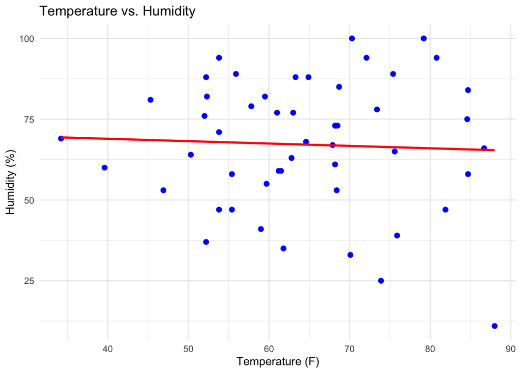

```r
# Create the scatterplot with a linear regression line
ggplot(final_weather_df, aes(x = Temp_F, y = Humidity)) +
  geom_point(color = "blue", size = 2) +
  geom_smooth(method = "lm", color = "red", se = FALSE) +
  theme_minimal() +
  labs(title = "Temperature vs. Humidity",
       x = "Temperature (F)",
       y = "Humidity (%)")
```

```r
temp_humid_model <- lm(Humidity ~ Temp_F, data = final_weather_df)
summary(temp_humid_model)
```

```
Call:
lm(formula = Humidity ~ Temp_F, data = final_weather_df)

Residuals:
    Min      1Q  Median      3Q     Max
-54.406 -11.815   0.686  14.367  33.947

Coefficients:
            Estimate Std. Error t value Pr(>|t|)
(Intercept) 71.87485   15.43683   4.656 2.57e-05 ***
Temp_F      -0.07351    0.23541  -0.312    0.756
---
Signif. codes:  0 '***' 0.001 '**' 0.01 '*' 0.05 '.' 0.1 ' ' 1

Residual standard error: 20.49 on 48 degrees of freedom
Multiple R-squared:  0.002027,  Adjusted R-squared:  -0.01876
F-statistic: 0.09752 on 1 and 48 DF,  p-value: 0.7562
```

#### Exercise 4

Create a bar chart of the EPA air quality index values. What does the distribution of air quality look like? Identify the location(s) with the best air quality and the worst air quality.

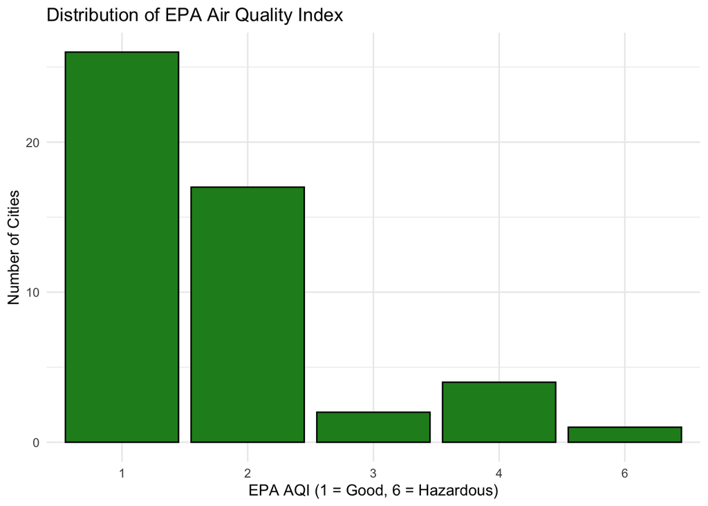

```r
ggplot(final_weather_df, aes(x = factor(EPA_AQI))) +
  geom_bar(fill = "forestgreen", color = "black") +
  theme_minimal() +
  labs(title = "Distribution of EPA Air Quality Index",
       x = "EPA AQI (1 = Good, 6 = Hazardous)",
       y = "Number of Cities")
```

```r
best_aqi_value <- min(final_weather_df$EPA_AQI, na.rm = TRUE)
worst_aqi_value <- max(final_weather_df$EPA_AQI, na.rm = TRUE)

cities_best_aqi <- final_weather_df %>%
  filter(EPA_AQI == best_aqi_value) %>%
  select(City, EPA_AQI)

cities_worst_aqi <- final_weather_df %>%
  filter(EPA_AQI == worst_aqi_value) %>%
  select(City, EPA_AQI)

cities_best_aqi
```

```
# A tibble: 26 × 2
   City              EPA_AQI
   <chr>               <int>
 1 Berlin                  1
 2 Zunyi                   1
 3 Rome                    1
 4 Guayaquil               1
 5 Daegu                   1
 6 Munich                  1
 7 Casablanca              1
 8 Fes-Saïss Airport       1
 9 Luanda                  1
10 Budapest                1
# ℹ 16 more rows
```

```r
cities_worst_aqi
```

```
# A tibble: 1 × 2
  City   EPA_AQI
  <chr>    <int>
1 Riyadh       6
```

#### Exercise 5

Create a bar chart of the current weather description. Which conditions are the most common? Which are the least?

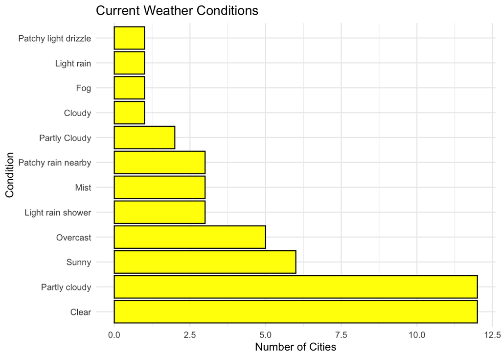

```r
ggplot(final_weather_df, aes(y = forcats::fct_infreq(Condition))) +
  geom_bar(fill = "yellow", color = "black") +
  theme_minimal() +
  labs(title = "Current Weather Conditions",
       x = "Number of Cities",
       y = "Condition")
```

```r
condition_counts <- final_weather_df %>%
  count(Condition, sort = TRUE)
```

### Part Two: Scraping Books

In this section, you’ll practice your web scraping skills by experimenting with a fictional online bookstore located at https://books.toscrape.com/. Use the tools that we demonstrate in class to do the following, in either R or Python (your choice):

#### Exercise 6

Scrape the first 20 results from this site. Create a data frame (or tibble) that stores the following for each book:

- Title
- Price (excluding tax)
- Star rating
- Whether the book is in stock

```r
library(rvest)

url <- "https://books.toscrape.com/"
page <- read_html(url)

# The site stores each book inside an <article> tag with the class "product_pod"
articles <- page %>% html_elements("article.product_pod")

# Extract Titles
titles <- articles %>%
  html_element("h3 a") %>%
  html_attr("title")

# Extract Prices
prices_raw <- articles %>%
  html_element("p.price_color") %>%
  html_text()
prices <- as.numeric(str_extract(prices_raw, "[0-9.]+"))

# Extract Star Ratings
stars_raw <- articles %>%
  html_element("p.star-rating") %>%
  html_attr("class") %>%
  str_remove("star-rating ")

# convert text numbers to actual numbers
star_mapping <- c("One" = 1, "Two" = 2, "Three" = 3, "Four" = 4, "Five" = 5)
stars <- star_mapping[stars_raw]

# In Stock
stock_raw <- articles %>%
  html_element("p.instock.availability") %>%
  html_text()
in_stock <- str_detect(stock_raw, "In stock")

books_df <- tibble(
  Title = titles,
  Price = prices,
  Stars = stars,
  In_Stock = in_stock
)
```

#### Exercise 7

Create a histogram of prices for these 20 books. What is the average price?

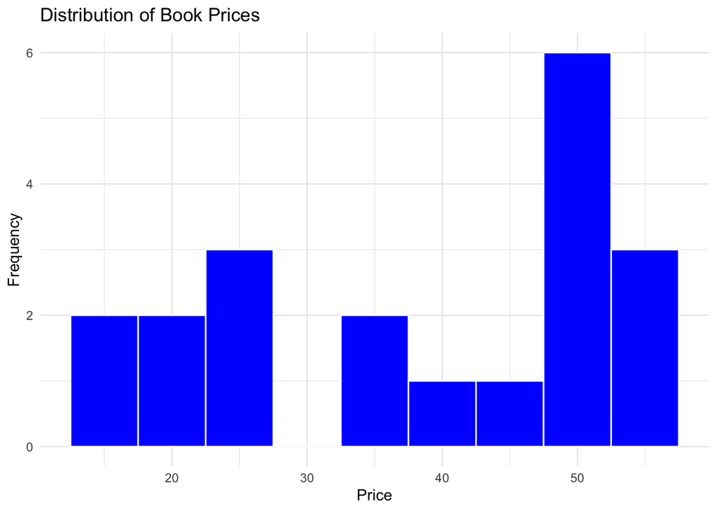

```r
ggplot(books_df, aes(x = Price)) +
  geom_histogram(binwidth = 5, fill = "blue", color = "white") +
  theme_minimal() +
  labs(title = "Distribution of Book Prices",
       x = "Price",
       y = "Frequency")
```

```r
average_price <- mean(books_df$Price)
average_price
```

```
[1] 38.0485
```

The average price is 38.0485 Euros.

#### Exercise 8

Create a bar chart of star rating for these 20 books. Find the book(s) with the highest and lowest star ratings.

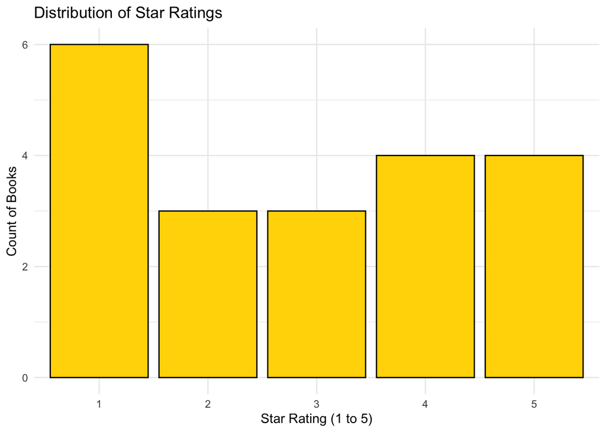

```r
ggplot(books_df, aes(x = factor(Stars, levels = 1:5))) +
  geom_bar(fill = "gold", color = "black") +
  theme_minimal() +
  labs(title = "Distribution of Star Ratings",
       x = "Star Rating (1 to 5)",
       y = "Count of Books")
```

```r
highest_rating_value <- max(books_df$Stars)
lowest_rating_value <- min(books_df$Stars)

best_books <- books_df %>%
  filter(Stars == highest_rating_value)

worst_books <- books_df %>%
  filter(Stars == lowest_rating_value)

best_books
```

```
# A tibble: 4 × 4
  Title                                                   Price Stars In_Stock
  <chr>                                                   <dbl> <dbl> <lgl>
1 Sapiens: A Brief History of Humankind                    54.2     5 TRUE
2 Set Me Free                                              17.5     5 TRUE
3 Scott Pilgrim's Precious Little Life (Scott Pilgrim #1)  52.3     5 TRUE
4 Rip it Up and Start Again                                35.0     5 TRUE
```

```r
worst_books
```

```
# A tibble: 6 × 4
  Title                                                 Price Stars In_Stock
  <chr>                                                 <dbl> <dbl> <lgl>
1 Tipping the Velvet                                     53.7     1 TRUE
2 Soumission                                             50.1     1 TRUE
3 The Requiem Red                                        22.6     1 TRUE
4 The Black Maria                                        52.2     1 TRUE
5 Olio                                                   23.9     1 TRUE
6 Mesaerion: The Best Science Fiction Stories 1800-1849  37.6     1 TRUE
```